# Danas attempt for Mihai’s project

Dana Jabari

23.01.2023

# Hey Mihai,

my last project will be yours :)

1. First task: Bar plots illustrating the CO2 uptake means (over the conc condition) for type and treatment groups, together with their respective standard errors.
- My struggle: How to make the error bar in the middle?

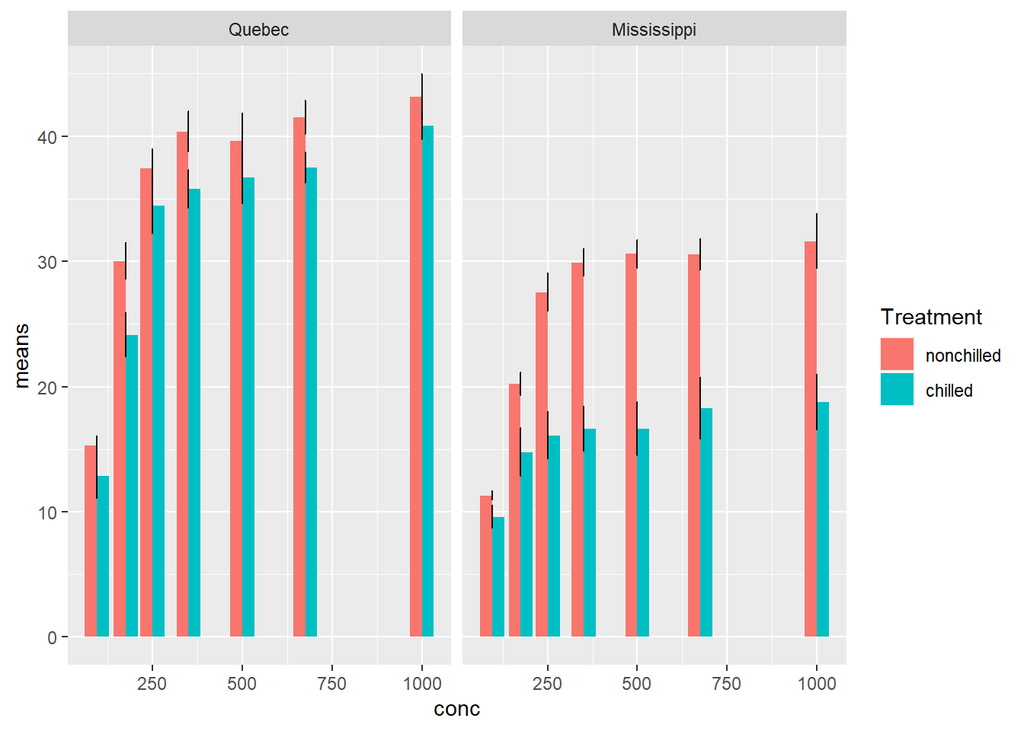

2. Line plots for each plant’s CO2 uptake over the conc condition (x-Axis) for all plants from Quebec.
- This kind of worked? At first the left axis the numbers were overlaying and I could not figure out, how to fix this. So I removed them. If you have a tip, I would love to know!

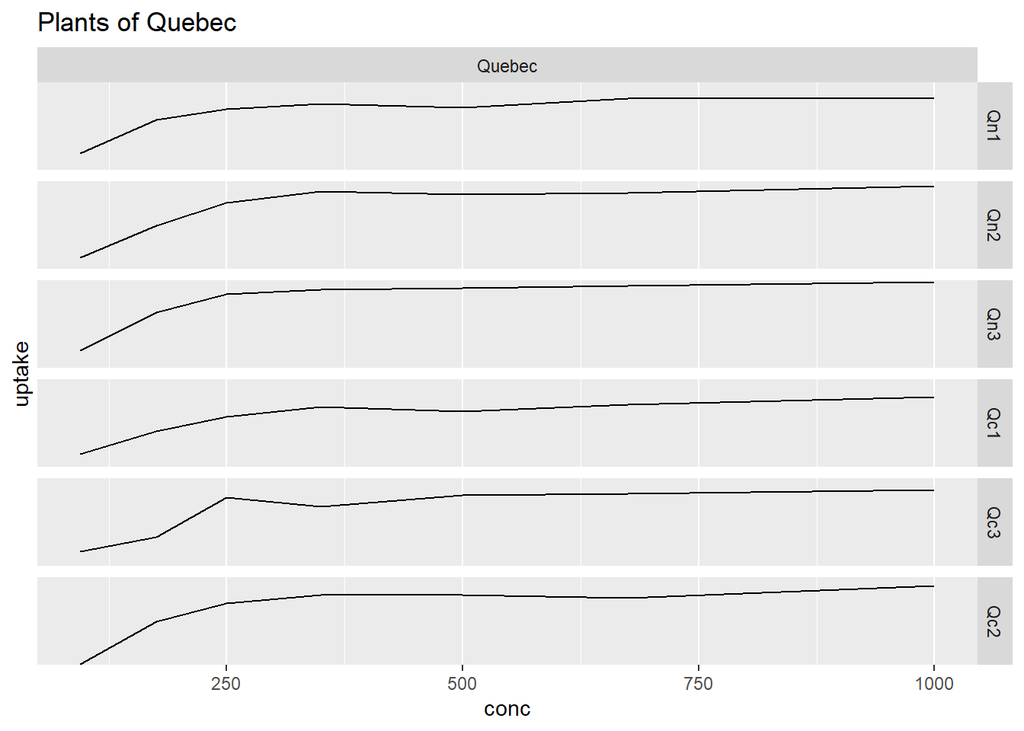

3. Formulating Hypothesises.
   - H0: Concentration level has no influence on the CO2 uptake of the plants.
   - H1: Concentration leven has an influence on the CO2 uptake of the plants.

```
##             Df Sum Sq Mean Sq F value   Pr(>F)
## conc         1   2285  2285.0   25.25 2.91e-06 ***
## Residuals   82   7422    90.5
## ---
## Signif. codes:  0 '***' 0.001 '**' 0.01 '*' 0.05 '.' 0.1 ' ' 1
```

With p < .001 H0 will be abolished. This means, that concentration has a significant impact on the C02 uptake of the plants.

Thank you for your project!

Best, Dana